# A Bayesian geostatistical approach to modelling global distributions of *Lygodium microphyllum* under projected climate warming

## Authors:

John M. Humphreys (jmh09r@my.fsu.edu)  
James B. Elsner  
Thomas H. Jagger  
Stephanie Pau

Portions of this study have been submitted for publication.  
Please contact authors at email address above to cite.

### Model Fitting

Model fitting and results available here: https://rpubs.com/JMHumphreys/LygPA020217

## Data Pre-processing

```r
date()
```

```
## [1] "Mon Mar 06 23:20:37 2017"
```

#### Options

```r
library(knitr)
library(rgl)
opts_knit$set(verbose = FALSE)
knit_hooks$set(webgl = hook_webgl)
```

### Load Packages:

```r
suppressMessages(library(INLA))
suppressMessages(library(rgdal))
suppressMessages(library(reshape2))
suppressMessages(library(raster))
suppressMessages(library(fields))
suppressMessages(library(rasterVis))
suppressMessages(library(rgeos))
suppressMessages(library(Thermimage))
suppressMessages(library(maptools))
suppressMessages(library(mapproj))
suppressMessages(library(spdep))
suppressMessages(library(ggplot2))
suppressMessages(library(GISTools))
suppressMessages(library(lattice))
suppressMessages(library(gridExtra))
suppressMessages(library(dismo))
suppressMessages(library(dplyr))
```

### Set Directory

```r
setwd("D:/Lygodium/LygProject/LygProject")
```

### Get Point Data

```r
Lyg.df = read.csv("D:/Lygodium/GBIF_data/MDat/REvCoord/LygMicro011917.csv",
                  header = TRUE, sep=",")

dim(Lyg.df)
```

```
## [1] 25016     5
```

```r
head(Lyg.df)
```

```
##   X               Species    Lat     Long Source
## 1 1 Lygodium microphyllum -32.47 152.2200      0
## 2 2 Lygodium microphyllum -32.30 152.1800      0
## 3 3 Lygodium microphyllum -32.30 152.1833      0
## 4 4 Lygodium microphyllum -32.30 152.1833      0
## 5 5 Lygodium microphyllum -30.87 152.1500      0
## 6 6 Lygodium microphyllum -30.72 152.9200      0
```

### Get Country Boundaries

```r
Countries = map("world",
                fill = TRUE,
                plot = FALSE)


IDs = sapply(strsplit(Countries$names, ":"), function(x) x[1])

LL84 = "+proj=longlat +datum=WGS84 +no_defs +ellps=WGS84 +towgs84=0,0,0"

CountriesP = map2SpatialPolygons(Countries, IDs = IDs,
                                proj4string = CRS(projection(LL84 )))

#Add a dataframe
pid = sapply(slot(CountriesP, "polygons"),
             function(x) slot(x, "ID"))

p.df = data.frame( ID=1:length(CountriesP),
                   row.names = pid)

Countries = SpatialPolygonsDataFrame(CountriesP, p.df)


#Rasterized version
Ras = raster(res = 0.9,
             crs = proj4string(Countries))

Domain.r = rasterize(Countries, Ras,
                     field = 0,
                     background = NA)
```

### Geographic Thinning

```r
r = raster(res = 0.042)

myLL = cbind(Lyg.df$Long, Lyg.df$Lat)

set.seed(1976)
DFSamp = as.data.frame(gridSample(myLL, r, n = 1))
names(DFSamp) = c("Long", "Lat")
```

### Remove Observations Over the Ocean

```r
LL = cbind(DFSamp$Long, DFSamp$Lat)
LygC = SpatialPointsDataFrame(LL, DFSamp)
proj4string(LygC) = LL84

N = length(LygC[,1])


###Remove Observations Over Oceans
LygC$ID = !is.na(over(LygC, Countries))[,1]
LygC = subset(LygC, ID == TRUE )

LygC@data = LygC@data[,1:3]

dim(LygC)
```

```
## [1] 1549    3
```

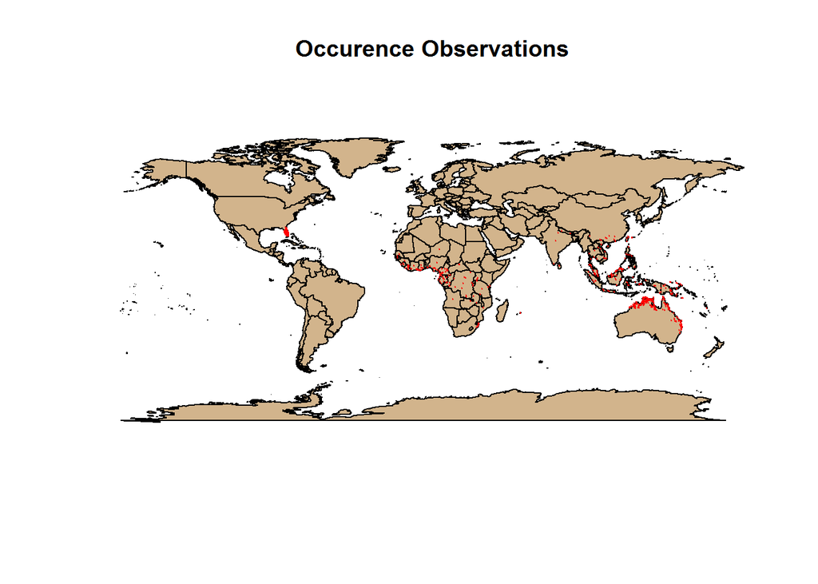

```r
plot(Countries, col="tan", main = "Occurence Observations")
plot(LygC, cex=0.1, pch=19, col="red", add=TRUE)
```

## Stochastic Partial Differential Equations (SPDE)

### Construct a mesh for the global domain (“mesh1”)

The mesh is constructed to have a greater number of triangulation over terrestrial regions.

```r
CountriesU = gBuffer(Countries, width = 1) #Smoothing edges

MaxEdge = 2.0

bdry = inla.sp2segment(CountriesU)

mesh2D = inla.mesh.2d(boundary = bdry,
                     cutoff = 1,
                     max.edge = MaxEdge,
                     min.angle = 21)

MeshLocs = cbind(mesh2D$loc[,1], mesh2D$loc[,2]) #Locations of mesh nodes

#Converting to 3D coordinates
xyz = as.data.frame(
          inla.mesh.map(MeshLocs,
                        projection = "longlat",
                        inverse = TRUE))

true.radius.of.earth = 6371
radius.of.earth = 1

mesh1 = inla.mesh.create(loc = xyz,
                         cutoff = 400/true.radius.of.earth,
                         refine=list(max.edge = 3500/true.radius.of.earth, min.angle = 26))

mesh1$n
```

```
## [1] 1284
```

```r
plot(mesh1, rgl = TRUE, main = " ")
```

[interactive chart not shown]

### Quadrature Points

A dense grid of points is created over terrestrial portions of the global domain. These will be combined with the mesh node locations below and used as quadrature.

```r
Grid.pnts = rasterToPoints(Domain.r, sp = TRUE)

Grid.pnts@data = Grid.pnts@data %>%
                  mutate(Long = Grid.pnts@coords[,1],
                         Lat = Grid.pnts@coords[,2],
                         OBS = 0,
                         Species = "Quad") %>%
                  select(-layer)
```

Additional quadrature points are drawn from each of the mesh vertices. Having both quadrature points located at mesh vertices helps avoid numerical issues.

```r
dd = as.data.frame(cbind(mesh1$loc[,1],
                         mesh1$loc[,2],
                         mesh1$loc[,3]))

#Convert to 2D long-lat to combine with quad points from the "dense grid"
dd = as.data.frame(
          inla.mesh.map(dd,
                        projection = "longlat",
                        inverse = FALSE))

names(dd) = c("Long", "Lat")


O.pnts = SpatialPointsDataFrame(dd, dd)
proj4string(O.pnts) = proj4string(LygC)
O.pnts = spTransform(O.pnts, CRS(proj4string(LygC)))


O.pnts@data = O.pnts@data %>%
              mutate(Long = O.pnts@coords[,1],
                     Lat = O.pnts@coords[,2],
                     OBS = 0,
                     Species = "Mesh")

Int.pnts = spRbind(Grid.pnts, O.pnts)
```

### Southeastern United States

A dense point grid is also created over covering the southeastern U.S. These locations will be used for later prediction.

This area includes states along the southeastern coastal plain (Florida, North Carolina, South Carolina, Georgia, Alabama, Mississippi, and Louisiana) as well as Arkansas and Tennessee.

#### Get State Boundaries

```r
ext = c(-91.29756, -77.76994,
         24.54233, 35.54766)

States = map("state",
            fill = TRUE,
            xlim = ext[1:2],
            ylim = ext[3:4],
            plot = FALSE)

IDs = sapply(strsplit(States$names, ":"),
             function(x) x[1])

StatesP = map2SpatialPolygons(States, IDs = IDs,
                              proj4string = CRS(projection(LygC)))
```

#### Rasterize and Create Points

```r
SEStates.r = raster(res = 0.75)
extent(SEStates.r) = extent(StatesP)

SEStates.r = rasterize(StatesP,
                       SEStates.r,
                       field = 0,
                       background = NA)

SEUS.pnts = rasterToPoints(SEStates.r, sp = TRUE)

SEUS.pnts@data = SEUS.pnts@data %>%
                  mutate(Long = SEUS.pnts@coords[,1],
                         Lat = SEUS.pnts@coords[,2],
                         OBS = 0,
                         Species = "SEUS") %>%
                  select(-layer)

Quad.pnts = spRbind(Int.pnts, SEUS.pnts)
```

### South East Asia and Oceania

A dense point grid is also created over covering the SE Asia and Oceania. These locations will be used for later prediction.

#### Get Country Boundaries

```r
coords = matrix(c(85, 40,
                  183, 40,
                  183, -50,
                  85, -50,
                  85, 40),
                 ncol = 2,
                 byrow = TRUE)


SEApoly = Polygon(coords)
SEApoly = SpatialPolygons(list(Polygons(list(SEApoly), ID = "a")),
                      proj4string=CRS("+proj=longlat +ellps=WGS84 +datum=WGS84 +no_defs"))

SEAsia.sp = crop(Countries, SEApoly)

####Rasterize and Create Points
SEAsia.r = raster(res = 0.4)
extent(SEAsia.r) = extent(SEAsia.sp)

SEAsia.r = rasterize(SEAsia.sp,
                     SEAsia.r,
                     field = 0,
                     background = NA)

SEAsia.pnts = rasterToPoints(SEAsia.r, sp = TRUE)

SEAsia.pnts@data = SEAsia.pnts@data %>%
                      mutate(Long = SEAsia.pnts@coords[,1],
                             Lat = SEAsia.pnts@coords[,2],
                             OBS = 0,
                             Species = "SEAsia") %>%
                      select(-layer)

Quad.pnts = spRbind(Quad.pnts, SEAsia.pnts)
```

### Mexico and Central America

These locations will be used for later prediction.

#### Get Country Boundaries

```r
coords = matrix(c(-109, 24.5,
                  -55, 24.5,
                  -55, -5,
                  -109, -5,
                  -109, 24.5),
                 ncol = 2,
                 byrow = TRUE)

MCpoly = Polygon(coords)
MCpoly = SpatialPolygons(list(Polygons(list(MCpoly), ID = "a")),
                      proj4string=CRS("+proj=longlat +ellps=WGS84 +datum=WGS84 +no_defs"))

MC.sp = crop(Countries, MCpoly)

####Rasterize and Create Points
MC.r = raster(res = 0.6)
extent(MC.r) = extent(MC.sp)

MC.r = rasterize(MC.sp,
                 MC.r,
                 field = 0,
                 background = NA)

MC.pnts = rasterToPoints(MC.r, sp = TRUE)

MC.pnts@data = MC.pnts@data %>%
                      mutate(Long = MC.pnts@coords[,1],
                             Lat = MC.pnts@coords[,2],
                             OBS = 0,
                             Species = "MC") %>%
                      select(-layer)

Quad.pnts = spRbind(Quad.pnts, MC.pnts)
```

### Combine Observation, Quadrature, and Prediction Points

```r
LygC@data = LygC@data %>%
              mutate(OBS = 1,
                     Species = "Lmic") %>%
              select(-ID)

LygPA.df = rbind(LygC@data, Quad.pnts@data)

row.names(LygPA.df) = 1:nrow(LygPA.df)

LygPA = SpatialPointsDataFrame(cbind(LygPA.df$Long,
                                     LygPA.df$Lat),
                               LygPA.df)

proj4string(LygPA) = CRS(proj4string(LygC))

LygPA@data = LygPA@data %>%
              mutate(Long = as.numeric(LygPA@coords[,1]),
                     Lat = as.numeric(LygPA@coords[,2]))
```

## Extract Potential Covariates

### Climate data

Source: http://www.worldclim.org/

```r
Bio = getData('worldclim',     #Current climate data (averages 1950 - 2000)
                var='bio',
                  res=2.5)


Bio70 = getData('CMIP5',       #Projected climate data, 8.5 RCP for the year 2070
                var='bio',
                    res=2.5,
                    rcp=85,
                    model='GS',
                    year=70)
```

### Population Density

Population Density  
http://sedac.ciesin.columbia.edu/data/set/gpw-v3-population-density

```r
Pop = raster("D:/Lygodium/gl_gpwv3_pdens_00_wrk_25/gldens00/glds00g/w001001.adf")
```

### Compound Topographic Index (CTI)

Also known as a “wetness index”. Calculated as the natural log of the upstream contributing area divided by the tangent of the slope for each cell.

```r
CTI = raster("D:/BulkData_dl/Global_LC/SRTMindx/cti.tif")
```

### Extract Covaraites to Point Locations

Also scaling values.

```r
LygPA@data = LygPA@data %>%
              mutate(mTcm = extract(Bio$bio6,
                                   spTransform(LygPA,
                                   CRS(proj4string(Bio$bio6))),
                                   method = "simple")/100,
                     mTcm70 = extract(Bio70$gs85bi706,
                                   spTransform(LygPA,
                                   CRS(proj4string(Bio70$gs85bi706))),
                                   method = "simple")/100,
                     Pwq = extract(Bio$bio16,
                                   spTransform(LygPA,
                                   CRS(proj4string(Bio$bio16))),
                                   method = "simple")/1000,
                     Pwq70 = extract(Bio70$gs85bi7016,
                                   spTransform(LygPA,
                                   CRS(proj4string(Bio70$gs85bi7016))),
                                   method = "simple")/1000,
                     Pop = extract(Pop,
                                   spTransform(LygPA,
                                   CRS(proj4string(Bio))),
                                   method = "simple")/1000,
                     CTI = extract(CTI,
                                   spTransform(LygPA,
                                   CRS(proj4string(CTI))),
                                   method = "simple")/10)
```

### Imputing Data

```r
df1 = LygPA@data

df1$Species = as.factor(df1$Species)

NEW = as.data.frame(
        df1 %>%
        group_by(Species) %>%
        mutate_each(funs(replace(., which(is.na(.)),
                                 mean(., na.rm=TRUE)))))[, 5:10]

apply(NEW, 2, range)
```

```
##       mTcm mTcm70   Pwq Pwq70      Pop       CTI
## [1,] -5.43  -5.08 0.000 0.000  0.00000 0.9435256
## [2,]  2.55   2.73 5.564 6.135 34.23955 2.5704475
```

```r
LygPA@data = cbind(LygPA@data[,1:4], NEW)
```

### Nearest Neighbor Distance

Distance to nearest plant occurrence.

```r
suppressMessages(library(spatstat))
nProj = "+proj=merc +a=6378137 +b=6378137 +lat_ts=0 +lon_0=0
         +x_0=0 +y_0=0 +k=1 +units=km +nadgrids=@null +no_defs"

P.pp = spTransform(LygPA, nProj)

By = as.factor(LygPA$Species)
P.pp = as.ppp(P.pp)

NN = (nndist(P.pp, by=By, k = 1))

LygPA$nLmic = NN[,"Lmic"]

range(LygPA$nLmic)
```

```
## [1] 5.456968e-12 2.580752e+04
```

```r
LygPA$NN = LygPA$nLmic/1000 #Scale
LygPA$NN = round(LygPA$NN, 2) #Rounding
```

### Subset Prediction Stack

Now that covariates have been collected for all locations, the set of points to be used for prediction are separated from those to be used for initial model fitting.

```r
SECP.pnts = subset(LygPA, Species == "SEUS") #Southeastern U.S. for prediction

SEAsia.pnts = subset(LygPA, Species == "SEAsia") #SE Asia and Oceania for prediction

MC.pnts = subset(LygPA, Species == "MC") #Mexico and Central America

World.pnts = subset(LygPA, Species != "SEUS" &
                           Species != "SEAsia" &
                           Species != "MC") #Global occurences and quadrature #26059
```

### Remove Duplicates

Removing quadrature points that are redundant to locations of mesh nodes.

```r
World.pnts$dups = duplicated(World.pnts@data[, c("Long","Lat")])

sum(World.pnts$dups) #Number of duplicates.
```

```
## [1] 1
```

```r
LygPA = subset(World.pnts, dups == FALSE)
```

### Assessing Covarites for Possible Colinearity Issues

Colldiag() is an implementation of the regression collinearity diagnostic procedures found in Belsley, Kuh, and Welsch (1980). These procedures examine the “conditioning” of the matrix of independent variables.

Colldiag() computes the condition indexes of the matrix. If the largest condition index (the condition number) is large (Belsley et al suggest 30 or higher), then there may be collinearity issues.

```r
Colin.df = LygPA@data %>%
            select(mTcm, Pwq, NN, Pop, CTI)

suppressMessages(library(perturb))

CI = colldiag(Colin.df)

CI
```

```
## Condition
## Index    Variance Decomposition Proportions
##           intercept mTcm  Pwq   NN    Pop   CTI
## 1   1.000 0.001     0.009 0.013 0.021 0.004 0.001
## 2   1.698 0.000     0.184 0.040 0.023 0.221 0.000
## 3   2.016 0.000     0.096 0.031 0.003 0.771 0.000
## 4   3.590 0.001     0.387 0.033 0.903 0.003 0.001
## 5   4.542 0.009     0.280 0.808 0.048 0.001 0.015
## 6  25.130 0.989     0.043 0.075 0.003 0.000 0.983
```

```r
detach("package:perturb", unload=TRUE)
```